# Mutiple regression models for evaluating the financial Performance of Pension Fund in Nigeria

## Introduction:

This study seeks to examine the effect of pension fund features such as density contribution, idle contribution, number of retirement savings account membership, expenditures, Fund Size, and Age of Fund, on the Financial performance of pension funds in Nigeria. The pension scheme currently operated in Nigeria requires all employees by law to maintain a Retirement Savings Account with any Pension Fund Administrator (PFA) of their choice, the financial performance of this RSA Fund managed by the PFA is our concern here. The measure for financial Performance used in this analysis includes the Investment Income, profit before tax and Total income or Gross revenue.

*Age of Fund*: This refers is how long the fund has existed. In this case, the age of the pension fund and the age of the Pension Fund Administrator are the same. Penson Fund are expected to be more profitable as their existence grow. In his research, Tijjani (2014) found that a pension fund administrator’s financial sustainability is projected to increase with age. Ajibade et al. (2018) in his work established that Age of fund has a significant positive effect on financial performance measured by Unit Price.

*Density of contribution*: This refers to the total pension contribution received by the pension fund. By law, the employers and employees are expected to contribute 10% and 8% respectively in Nigeria. In Kigen (2016), research´s it was established that the contribution has a positive significant regression coefficient in predicting the financial performance of pension funds. This result however contradicts the outcome of Ajibade et al. (2018) research that suggest that contribution has a significant negative effect on financial performance and Oluoch (2013) study which suggests that the variable contribution is not a significant factor.

*Idle contribution*: This relates to the contributions made by the Pension fund’s beneficiaries that have not been put to use, that is, earning no interest or other form of investment income as a result. While it is important to ensure that optimal cash is available for liquidity needs, such as meeting obligations to retirees, having huge amount of idle fund may not be considered a good investment strategy. Ajibade et al. (2018) suggest in their study that idle contribution has a significant and positive effect on the financial Performance of pension fund.

*Number of Retirement Savings Account membership*: This variable is explained simply as the number of registered members of the pension scheme. Although this number is increasing over the years, there is still a huge shortfall in comparison to the number of working age population, and this can be associated with high unemployment rate faced in Nigeria amongst other things. This variable has been considered by Kigen (2016) in his research, and he suggest that it is has no significant relationship with the performance of pension funds.

*Fund size*: This variable was proxy by Net Pension Asset Under Management. According to studies (Gallagher and Martin 2005), a pension fund’s performance improves as it grows in size. The outcome of Kigen (2016) study shows that fund size has a negative and significant relationship with the financial performance of pension funds. While the result of Oluoch (2013) shows that there is no significant relationship between the asset and financial performance of pension fund.

*Expenditure*: In this study expenditure is proxy by Asset based Fees and Vat. According to Tijjani (2014), Pension Fund Administrators must make sure that their income always exceeds their expenses in order to retain strong financial standing throughout time. In the studies of Kigen (2016), administrative expenditure has a positive significance influence over financial performance of pension funds. This is contrary to the work of Ajibade et al. (2018) where it was established that this variable has no significant effect.

### Initial trail (IT) Models:

Due to the dearth of data, initial data collection and analysis process for the various variables was centered around the cumulative values for all Pension fund Administrators for each year from 2012 to 2021, which implies that we only have 10years observations, and the defined variables below were used. This data collection style is similar to that used in the study carry out by Oluoch (2013).

| Definition of Variables | Definition of Variables |
| --- | --- |
| Dependent Varible | Investment income (Inv.Inc) |
| Dependent Varible | Fund Size (AUM) |
| Independent Varible | Density of COntribuitons (DC) |
| Independent Varible | Expenditure (EXPF) |
| Independent Varible | Retirement Savings Account Memebership (RSAM) |

*IT_MODEL Version 1:* Where the dependent variable is measured as investment income, derived as an aggregate of Interest/Coupons, Dividends and Net unrealized Gains/(Losses) on quoted equities / equity funds for all PFA during each year; and independent variables includes EXPF, DC, and RSAM, derived as relative values, that is the values recorded during each year.

```r
library(lessR)
```

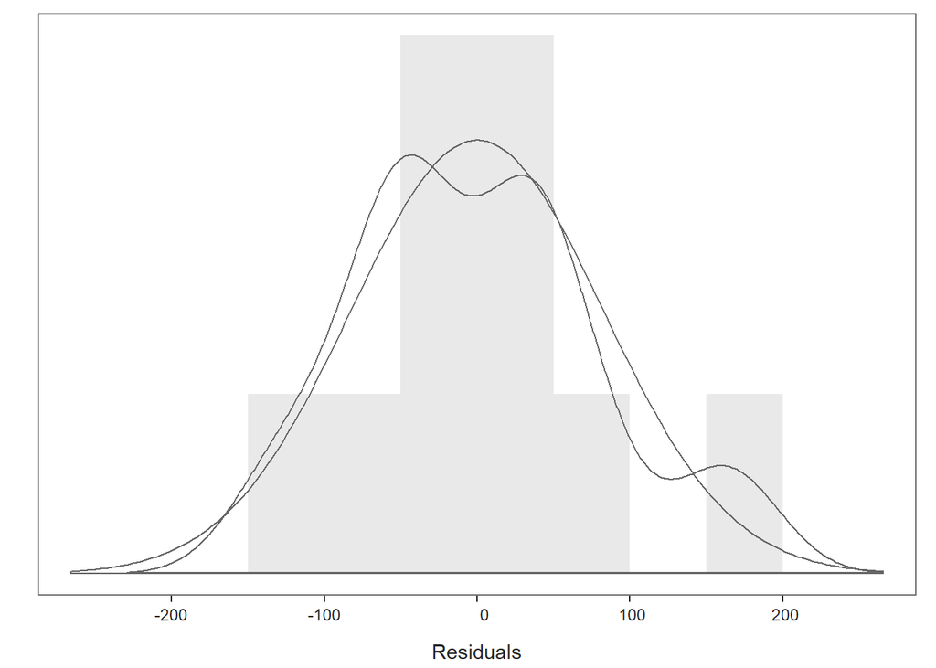

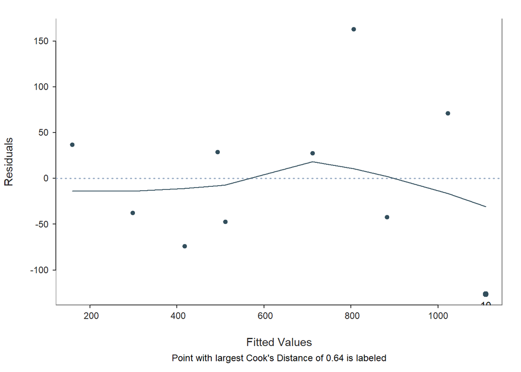

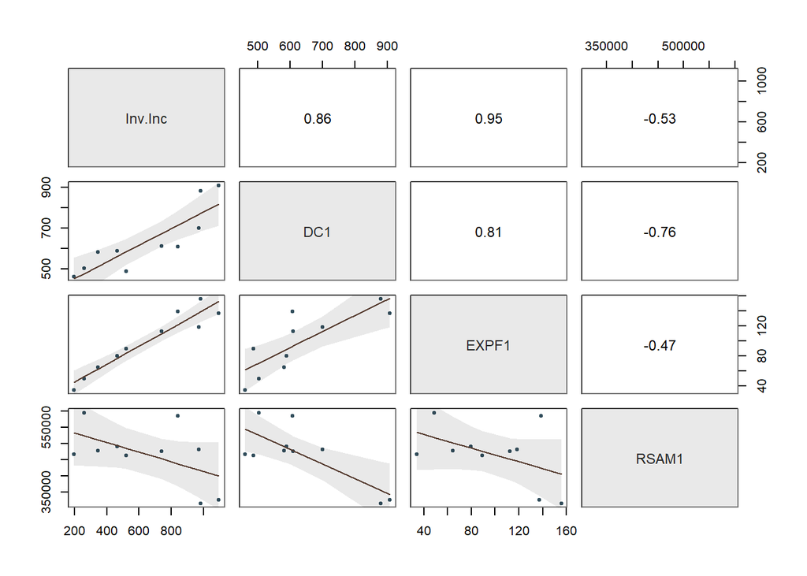

```
## >>> Suggestion
## # Create an R markdown file for interpretative output with  Rmd = "file_name"
## Regression(my_formula=Inv.Inc ~ DC1 + EXPF1 + RSAM1, data=ThesisData, Rmd="eg")
##
##
##   BACKGROUND
##
## Data Frame:  ThesisData
##
## Response Variable: Inv.Inc
## Predictor Variable 1: DC1
## Predictor Variable 2: EXPF1
## Predictor Variable 3: RSAM1
##
## Number of cases (rows) of data:  10
## Number of cases retained for analysis:  10
##
##
##   BASIC ANALYSIS
##
##              Estimate    Std Err  t-value  p-value   Lower 95%   Upper 95%
## (Intercept)  -435.073    505.528   -0.861    0.422   -1672.056     801.909
##         DC1     0.669      0.543    1.232    0.264      -0.660       1.999
##       EXPF1     5.751      1.504    3.823    0.009       2.070       9.432
##       RSAM1     0.000      0.001    0.314    0.764      -0.001       0.002
##
## Standard deviation of Inv.Inc: 325.723
##
## Standard deviation of residuals:  101.194 for 6 degrees of freedom
## 95% range of residual variation:  495.224 = 2 * (2.447 * 101.194)
##
## R-squared:  0.936    Adjusted R-squared:  0.903    PRESS R-squared:  0.827
##
## Null hypothesis of all 0 population slope coefficients:
##   F-statistic: 29.082     df: 3 and 6     p-value:  0.001
##
## -- Analysis of Variance
##
##             df      Sum Sq     Mean Sq   F-value   p-value
##       DC1    1  708437.277  708437.277    69.182     0.000
```

[output cut: 63 more lines]

```
##    2 503.920  48.960     595510  260.820  298.295 125.993   -9.999  606.589 616.589
##    3 581.380  64.580     477295  343.460  417.260 111.171  145.234  689.285 544.052
##    5 488.200  89.080     462632  521.700  492.969 127.819  180.206  805.731 625.525
##    4 588.960  79.600     489727  463.910  511.106 107.444  248.199  774.012 525.813
##    6 610.840 112.350     475883  738.860  711.442 110.274  441.612  981.272 539.659
##    8 700.690 118.200     481052  969.240  806.227 110.075  536.884 1075.570 538.686
##    7 607.560 138.730     586273  840.050  882.179 130.782  562.167 1202.192 640.026
##    9 908.090 136.900     324552 1093.630 1022.531 125.149  716.302 1328.759 612.457
##   10 880.660 155.590     313431  982.950 1109.520 122.577  809.585 1409.455 599.870
##
## ----------------------------------
## Plot 1: Distribution of Residuals
## Plot 2: Residuals vs Fitted Values
## Plot 3: ScatterPlot Matrix
## ----------------------------------
```

```r
ThesisData <-read.csv(file.choose(), header = T)
Regression(Inv.Inc ~ DC1 + EXPF1 + RSAM1,data= ThesisData)
```

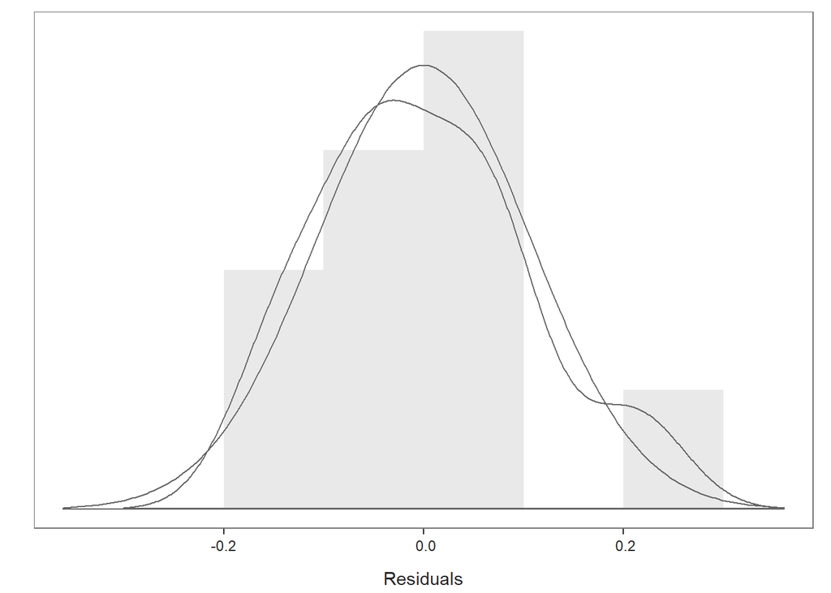

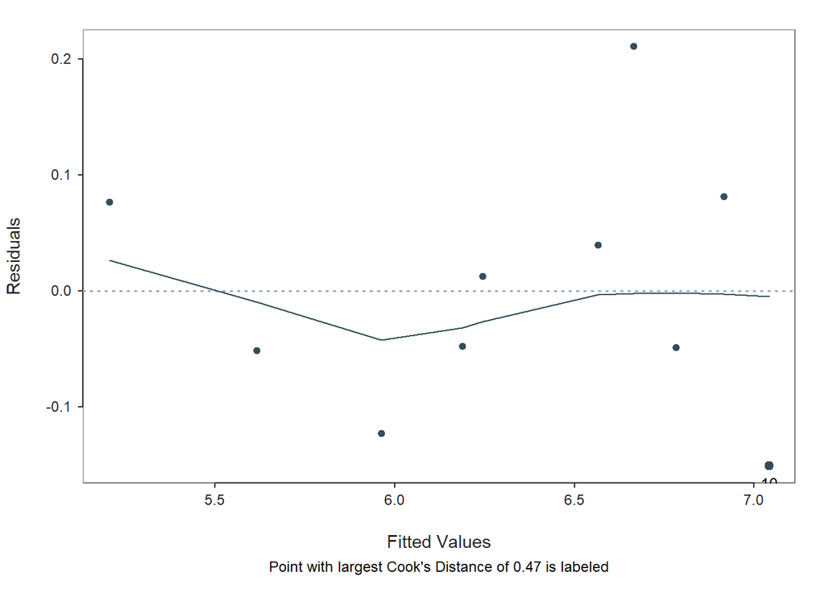

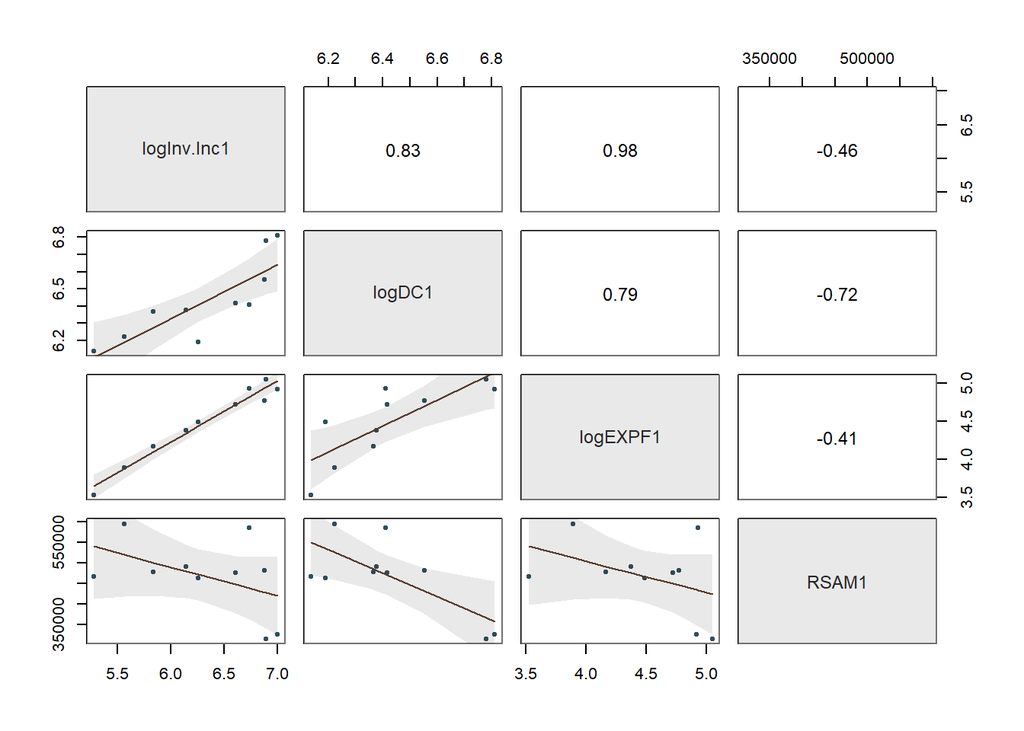

```
## >>> Suggestion
## # Create an R markdown file for interpretative output with  Rmd = "file_name"
## Regression(my_formula=logInv.Inc1 ~ logDC1 + logEXPF1 + RSAM1, data=log_T1, Rmd="eg")
##
##
##   BACKGROUND
##
## Data Frame:  log_T1
##
## Response Variable: logInv.Inc1
## Predictor Variable 1: logDC1
## Predictor Variable 2: logEXPF1
## Predictor Variable 3: RSAM1
##
## Number of cases (rows) of data:  10
## Number of cases retained for analysis:  10
##
##
##   BASIC ANALYSIS
##
##               Estimate    Std Err  t-value  p-value    Lower 95%   Upper 95%
## (Intercept) -0.5822206  2.5694422   -0.227    0.828   -6.8694192   5.7049780
##      logDC1  0.3376880  0.4354456    0.775    0.467   -0.7278089   1.4031850
##    logEXPF1  1.0596280  0.1539489    6.883    0.000    0.6829287   1.4363274
##       RSAM1 -0.0000000  0.0000007   -0.062    0.953   -0.0000018   0.0000018
##
## Standard deviation of logInv.Inc1: 0.6022577
##
## Standard deviation of residuals:  0.1316198 for 6 degrees of freedom
## 95% range of residual variation:  0.6441242 = 2 * (2.447 * 0.1316198)
##
## R-squared:  0.968    Adjusted R-squared:  0.952    PRESS R-squared:  0.921
##
## Null hypothesis of all 0 population slope coefficients:
##   F-statistic: 60.812     df: 3 and 6     p-value:  0.000
##
## -- Analysis of Variance
##
##                df     Sum Sq    Mean Sq      F-value   p-value
##      logDC1     1  2.2242176  2.2242176  128.3910316     0.000
```

[output cut: 63 more lines]

```
##    2 6.2224175 3.8910036         595510   5.5638305 5.6149408 0.1614144 5.2199739 6.0099077 0.7899338
##    3 6.3654046 4.1679048         477295   5.8390707 5.9620159 0.1419980 5.6145592 6.3094725 0.6949133
##    5 6.1907252 4.4895348         462632   6.2570927 6.2445040 0.1737913 5.8192520 6.6697560 0.8505040
##    4 6.3783583 4.3770141         489727   6.1396906 6.1874027 0.1386205 5.8482106 6.5265948 0.6783842
##    6 6.4148351 4.7216190         475883   6.6051085 6.5655033 0.1432714 6.2149308 6.9160758 0.7011450
##    8 6.5520656 4.7723781         481052   6.8765123 6.6653950 0.1442460 6.3124379 7.0183522 0.7059143
##    7 6.4094509 4.9325296         586273   6.7334614 6.7821501 0.1646340 6.3793053 7.1849948 0.8056895
##    9 6.8113435 4.9192507         324552   6.9972577 6.9157000 0.1600296 6.5241217 7.3072782 0.7831565
##   10 6.7806716 5.0472243         313431   6.8905583 7.0414528 0.1580536 6.6547095 7.4281960 0.7734865
##
## ----------------------------------
## Plot 1: Distribution of Residuals
## Plot 2: Residuals vs Fitted Values
## Plot 3: ScatterPlot Matrix
## ----------------------------------
```

```r
log_T1 <- transform(ThesisData, logInv.Inc1 = log(Inv.Inc),logDC1 = log(DC1),logEXPF1 = log(EXPF1)) # LOG transformation
Regression(logInv.Inc1  ~ logDC1 + logEXPF1 + RSAM1,data= log_T1)
```

**IT_MODEL Version 2:** Where the Fund Size (AUM) represents the dependent variable;and independent variables includes EXPF, DC, and RSAM, derived as relative values, that is the values recorded during each year.

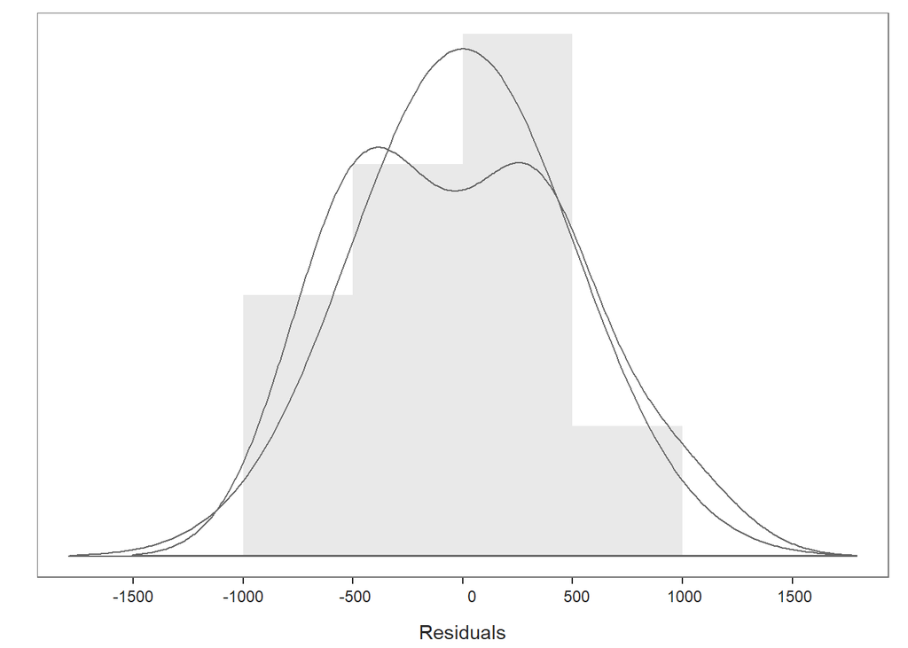

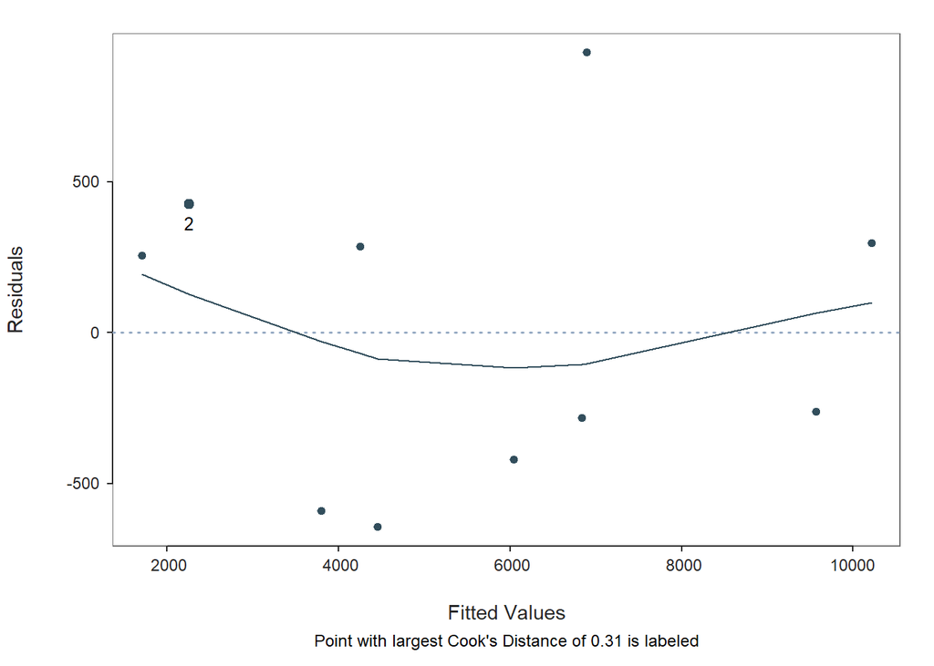

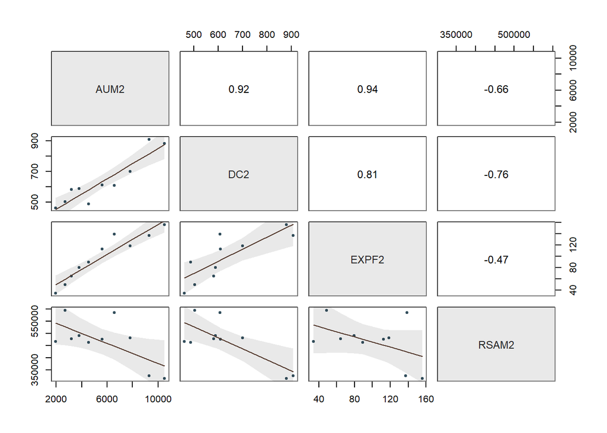

```
## >>> Suggestion
## # Create an R markdown file for interpretative output with  Rmd = "file_name"
## Regression(my_formula=AUM2 ~ DC2 + EXPF2 + RSAM2, data=ThesisData_v2, Rmd="eg")
##
##
##   BACKGROUND
##
## Data Frame:  ThesisData_v2
##
## Response Variable: AUM2
## Predictor Variable 1: DC2
## Predictor Variable 2: EXPF2
## Predictor Variable 3: RSAM2
##
## Number of cases (rows) of data:  10
## Number of cases retained for analysis:  10
##
##
##   BASIC ANALYSIS
##
##              Estimate    Std Err  t-value  p-value   Lower 95%   Upper 95%
## (Intercept) -1573.955   3139.943   -0.501    0.634   -9257.119    6109.210
##         DC2     6.837      3.375    2.026    0.089      -1.422      15.097
##       EXPF2    42.818      9.345    4.582    0.004      19.952      65.684
##       RSAM2    -0.003      0.004   -0.755    0.479      -0.012       0.006
##
## Standard deviation of AUM2: 2,895.199
##
## Standard deviation of residuals:  628.542 for 6 degrees of freedom
## 95% range of residual variation:  3,075.971 = 2 * (2.447 * 628.542)
##
## R-squared:  0.969    Adjusted R-squared:  0.953    PRESS R-squared:  0.925
##
## Null hypothesis of all 0 population slope coefficients:
##   F-statistic: 61.652     df: 3 and 6     p-value:  0.000
##
## -- Analysis of Variance
##
##             df        Sum Sq       Mean Sq   F-value   p-value
##       DC2    1  64373334.210  64373334.210   162.944     0.000
```

[output cut: 63 more lines]

```
##    2 503.920  48.960     595510  2687.080  2260.025 782.575  345.132  4174.918 3829.786
##    3 581.380  64.580     477295  3206.640  3797.511 690.514 2107.884  5487.138 3379.254
##    5 488.200  89.080     462632  4537.510  4251.496 793.920 2308.842  6194.149 3885.306
##    4 588.960  79.600     489727  3813.140  4456.812 667.365 2823.828  6089.796 3265.968
##    6 610.840 112.350     475883  5629.450  6048.412 684.942 4372.421  7724.404 3351.983
##    7 607.560 138.728     586273  6557.350  6838.846 812.326 4851.155  8826.537 3975.382
##    8 700.690 118.196     481052  7828.990  6898.243 683.704 5225.280  8571.207 3345.927
##    9 908.090 136.900     324552  9304.790  9566.040 777.334 7663.971 11468.109 3804.137
##   10 880.660 155.590     313431 10507.630 10210.654 761.359 8347.675 12073.634 3725.959
##
## ----------------------------------
## Plot 1: Distribution of Residuals
## Plot 2: Residuals vs Fitted Values
## Plot 3: ScatterPlot Matrix
## ----------------------------------
```

```r
ThesisData_v2 <-read.csv(file.choose(), header = T)
Regression(AUM2 ~ DC2 + EXPF2 + RSAM2,data= ThesisData_v2)
```

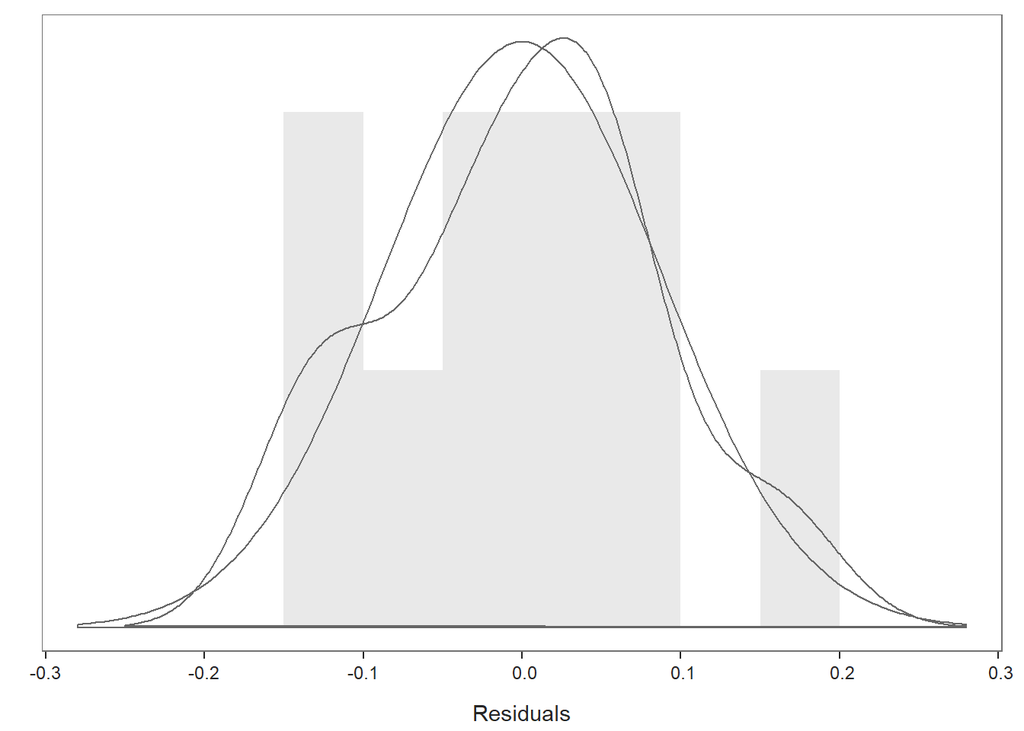

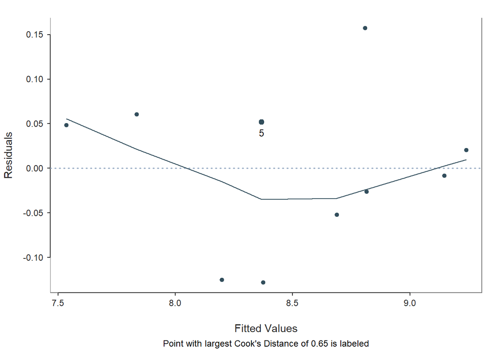

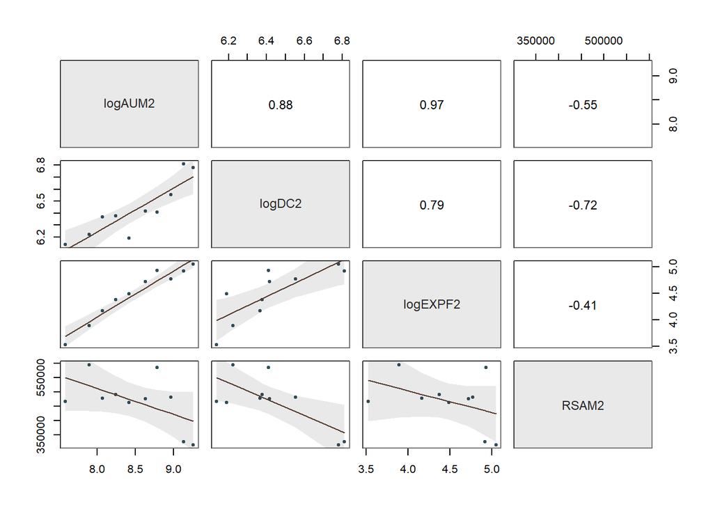

```
## >>> Suggestion
## # Create an R markdown file for interpretative output with  Rmd = "file_name"
## Regression(my_formula=logAUM2 ~ logDC2 + logEXPF2 + RSAM2, data=log_T2, Rmd="eg")
##
##
##   BACKGROUND
##
## Data Frame:  log_T2
##
## Response Variable: logAUM2
## Predictor Variable 1: logDC2
## Predictor Variable 2: logEXPF2
## Predictor Variable 3: RSAM2
##
## Number of cases (rows) of data:  10
## Number of cases retained for analysis:  10
##
##
##   BASIC ANALYSIS
##
##               Estimate    Std Err  t-value  p-value    Lower 95%   Upper 95%
## (Intercept)  1.1891952  2.0980395    0.567    0.591   -3.9445226   6.3229130
##      logDC2  0.5876234  0.3555570    1.653    0.149   -0.2823932   1.4576401
##    logEXPF2  0.8309034  0.1257063    6.610    0.001    0.5233113   1.1384956
##       RSAM2 -0.0000004  0.0000006   -0.679    0.523   -0.0000019   0.0000011
##
## Standard deviation of logAUM2: 0.5538428
##
## Standard deviation of residuals:  0.1074730 for 6 degrees of freedom
## 95% range of residual variation:  0.5259541 = 2 * (2.447 * 0.1074730)
##
## R-squared:  0.975    Adjusted R-squared:  0.962    PRESS R-squared:  0.941
##
## Null hypothesis of all 0 population slope coefficients:
##   F-statistic: 77.670     df: 3 and 6     p-value:  0.000
##
## -- Analysis of Variance
##
##              df     Sum Sq    Mean Sq      F-value   p-value
##    logDC2     1  2.1486305  2.1486305  186.0213132     0.000
```

[output cut: 63 more lines]

```
##    2 6.2224175 3.8910036         595510 7.8962104 7.8354442 0.1318012 7.5129382 8.1579502 0.6450120
##    3 6.3654046 4.1679048         477295 8.0729789 8.1978301 0.1159472 7.9141175 8.4815427 0.5674251
##    5 6.1907252 4.4895348         462632 8.4201337 8.3684170 0.1419077 8.0211813 8.7156527 0.6944714
##    4 6.3783583 4.3770141         489727 8.2462083 8.3741137 0.1131893 8.0971494 8.6510781 0.5539287
##    6 6.4148351 4.7216190         475883 8.6357670 8.6875364 0.1169873 8.4012789 8.9737939 0.5725150
##    7 6.4094509 4.9325155         586273 8.7883418 8.8145180 0.1344305 8.4855784 9.1434577 0.6578793
##    8 6.5520656 4.7723438         481052 8.9655888 8.8082123 0.1177828 8.5200081 9.0964165 0.5764084
##    9 6.8113435 4.9192507         324552 9.1382846 9.1465585 0.1306707 8.8268189 9.4662981 0.6394792
##   10 6.7806716 5.0472243         313431 9.2598569 9.2394111 0.1290573 8.9236191 9.5552030 0.6315839
##
## ----------------------------------
## Plot 1: Distribution of Residuals
## Plot 2: Residuals vs Fitted Values
## Plot 3: ScatterPlot Matrix
## ----------------------------------
```

```r
log_T2 <- transform(ThesisData_v2, logAUM2 = log(AUM2),logDC2 = log(DC2),logEXPF2 = log(EXPF2)) # LOG transformation
Regression(logAUM2 ~ logDC2 + logEXPF2 + RSAM2,data= log_T2)
```

*IT_MODEL Version 3:* Where both investment income (Inv.Inc) and Fund Size (AUM) are alternated as a measure of dependent varaible;and independent variables includes AUM, EXPF, DC, and RSAM, derived as Cummulative values, that is the values recorded from inception to each year.

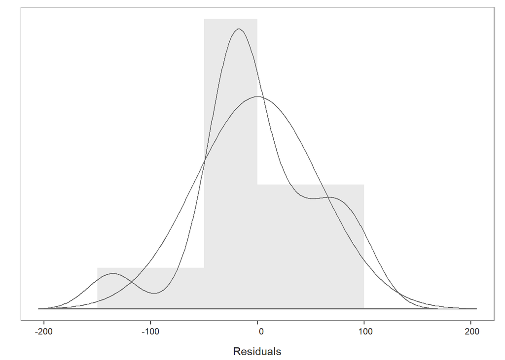

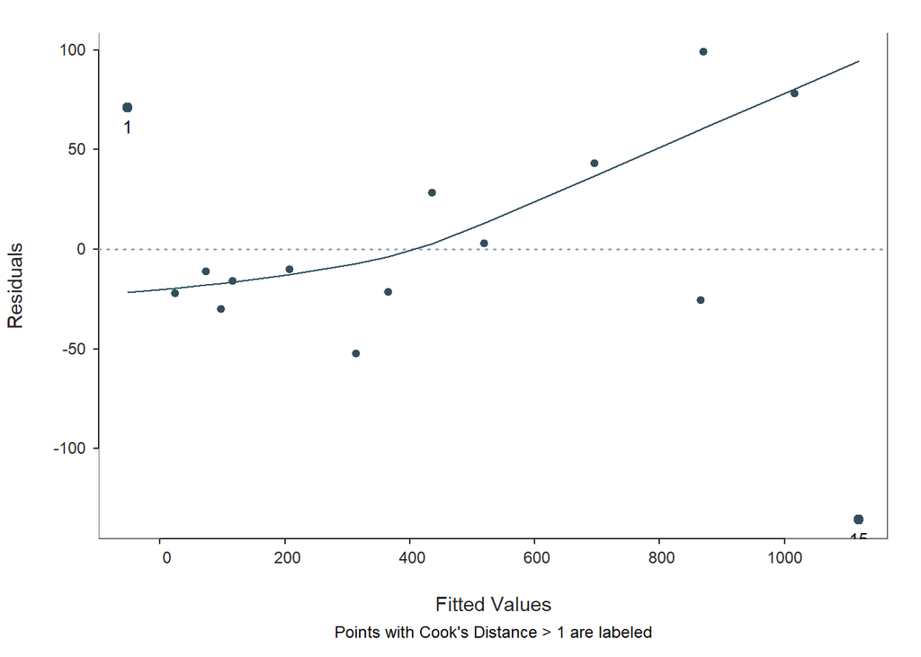

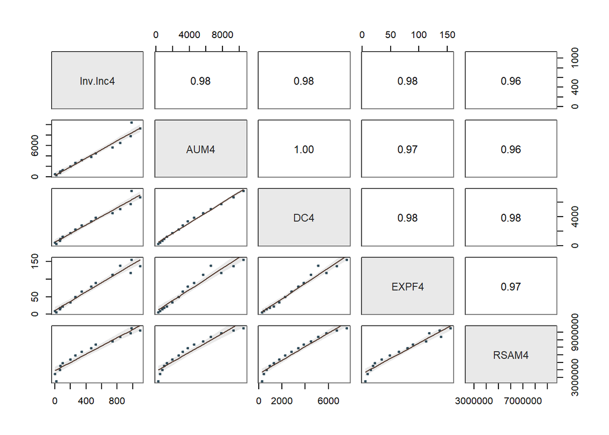

```
## >>> Suggestion
## # Create an R markdown file for interpretative output with  Rmd = "file_name"
## Regression(my_formula=Inv.Inc4 ~ AUM4 + DC4 + EXPF4 + RSAM4, data=ThesisData_v4, Rmd="eg")
##
##
##   BACKGROUND
##
## Data Frame:  ThesisData_v4
##
## Response Variable: Inv.Inc4
## Predictor Variable 1: AUM4
## Predictor Variable 2: DC4
## Predictor Variable 3: EXPF4
## Predictor Variable 4: RSAM4
##
## Number of cases (rows) of data:  15
## Number of cases retained for analysis:  15
##
##
##   BASIC ANALYSIS
##
##               Estimate    Std Err  t-value  p-value    Lower 95%   Upper 95%
## (Intercept) -231.74369  179.40651   -1.292    0.226   -631.48631   167.99893
##        AUM4    0.17551    0.10785    1.627    0.135     -0.06478     0.41581
##         DC4   -0.23525    0.21348   -1.102    0.296     -0.71092     0.24041
##       EXPF4    4.18764    2.21707    1.889    0.088     -0.75229     9.12757
##       RSAM4    0.00007    0.00006    1.137    0.282     -0.00006     0.00020
##
## Standard deviation of Inv.Inc4: 389.58197
##
## Standard deviation of residuals:  69.11526 for 10 degrees of freedom
## 95% range of residual variation:  307.99680 = 2 * (2.228 * 69.11526)
##
## R-squared:  0.978    Adjusted R-squared:  0.969    PRESS R-squared:  0.901
##
## Null hypothesis of all 0 population slope coefficients:
##   F-statistic: 108.703     df: 4 and 10     p-value:  0.000
##
## -- Analysis of Variance
##
```

[output cut: 86 more lines]

```
##    7  2687.08000 2247.79000  48.96000       5919299  260.82000  312.99511 74.63247  146.70360  479.28662 332.58303
##    8  3206.64000 2829.06000  64.58000       6396574  343.46000  364.85132 74.99966  197.74166  531.96099 334.21933
##    9  3813.14000 3388.02000  79.60000       6885396  463.91000  435.47661 80.96246  255.08102  615.87220 360.79119
##   10  4537.51000 3876.21000  89.08000       7348028  521.70000  518.48259 79.27872  341.83859  695.12660 353.28801
##   11  5629.45000 4487.40000 112.35000       7823911  738.86000  695.70118 76.52057  525.20272  866.19963 340.99691
##   12  6557.35000 5094.88000 138.72804       8410184  840.05141  865.41889 91.56382  661.40199 1069.43580 408.03381
##   13  7828.99000 5795.65000 118.19594       8891236  969.24314  870.02196 78.96113  694.08560 1045.95833 351.87274
##   14  9304.79000 6703.74000 136.90000       9215788 1093.63000 1015.49821 80.79676  835.47181 1195.52460 360.05279
##   15 10507.63000 7584.40000 155.59000       9529127  982.95000 1118.70921 86.18576  926.67537 1310.74305 384.06768
##
## ----------------------------------
## Plot 1: Distribution of Residuals
## Plot 2: Residuals vs Fitted Values
## Plot 3: ScatterPlot Matrix
## ----------------------------------
```

```r
ThesisData_v4 <-read.csv(file.choose(), header = T)
Regression(Inv.Inc4 ~ AUM4 + DC4 + EXPF4 + RSAM4,data= ThesisData_v4)
```

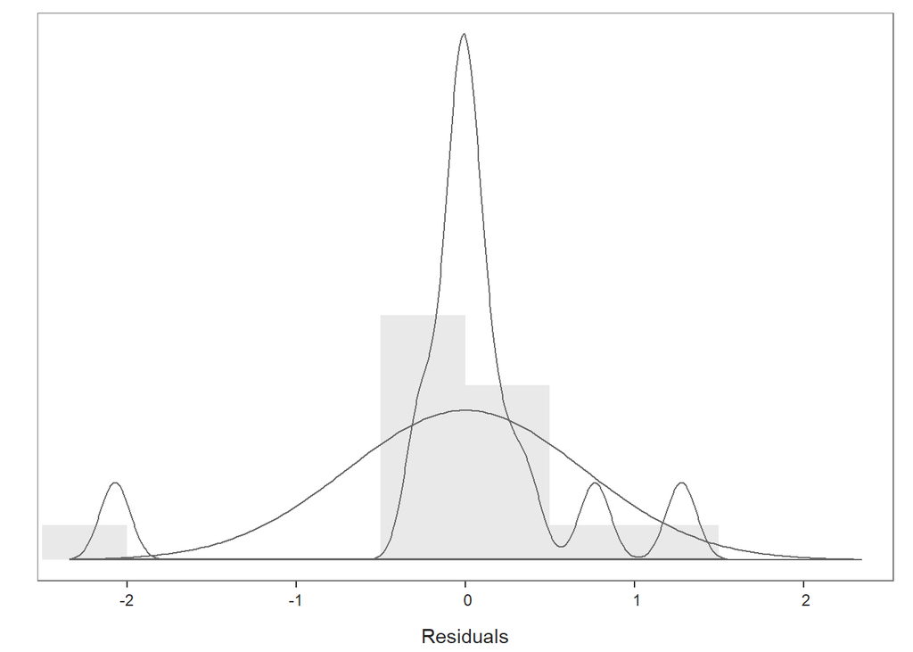

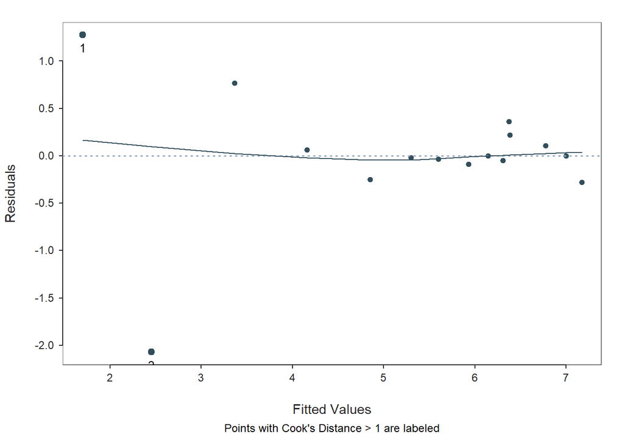

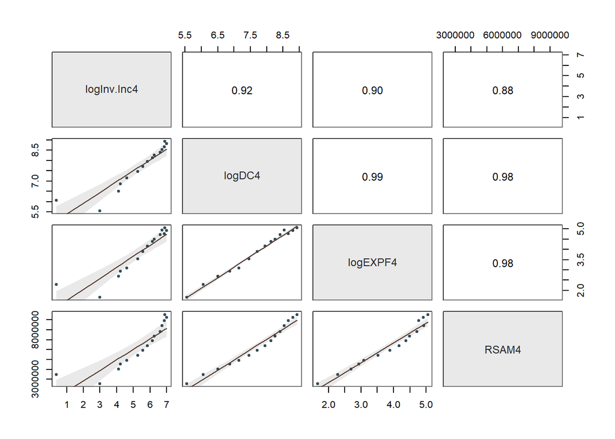

```
## >>> Suggestion
## # Create an R markdown file for interpretative output with  Rmd = "file_name"
## Regression(my_formula=logInv.Inc4 ~ logDC4 + logEXPF4 + RSAM4, data=log_T3, Rmd="eg")
##
##
##   BACKGROUND
##
## Data Frame:  log_T3
##
## Response Variable: logInv.Inc4
## Predictor Variable 1: logDC4
## Predictor Variable 2: logEXPF4
## Predictor Variable 3: RSAM4
##
## Number of cases (rows) of data:  15
## Number of cases retained for analysis:  15
##
##
##   BASIC ANALYSIS
##
##                 Estimate     Std Err  t-value  p-value      Lower 95%    Upper 95%
## (Intercept) -14.97395646  9.09640091   -1.646    0.128   -34.99499988   5.04708697
##      logDC4   3.48807912  2.20536931    1.582    0.142    -1.36590600   8.34206424
##    logEXPF4  -0.98228900  1.94010165   -0.506    0.623    -5.25242393   3.28784593
##       RSAM4  -0.00000043  0.00000049   -0.872    0.402    -0.00000150   0.00000065
##
## Standard deviation of logInv.Inc4: 1.81662406
##
## Standard deviation of residuals:  0.78926292 for 11 degrees of freedom
## 95% range of residual variation:  3.47431197 = 2 * (2.201 * 0.78926292)
##
## R-squared:  0.852    Adjusted R-squared:  0.811    PRESS R-squared:  0.611
##
## Null hypothesis of all 0 population slope coefficients:
##   F-statistic: 21.056     df: 3 and 11     p-value:  0.000
##
## -- Analysis of Variance
##
##                  df       Sum Sq      Mean Sq      F-value   p-value
##      logDC4       1  38.68851161  38.68851161  62.10672337     0.000
```

[output cut: 73 more lines]

```
##    7 7.71770279 3.89100364          5919299  5.56383051 5.60077548 0.85674078  3.71510173 7.48644923 3.77134750
##    8 7.94769978 4.16790477          6396574  5.83907066 5.92758498 0.86397899  4.02598004 7.82918992 3.80320988
##    9 8.12800096 4.37701409          6885396  6.13969057 6.14272072 0.85791530  4.25446188 8.03097956 3.77651768
##   12 8.53599139 4.93251547          8410184  6.73346309 6.37021091 0.93074429  4.32165654 8.41876528 4.09710873
##   10 8.26261315 4.48953484          7348028  6.25709271 6.30453120 0.83671400  4.46293610 8.14612629 3.68319020
##   11 8.40902875 4.72161900          7823911  6.60510846 6.38441875 0.86466498  4.48130395 8.28753354 3.80622959
##   13 8.66486292 4.77234376          8891236  6.87651550 6.77200865 0.89083621  4.81129137 8.73272593 3.92143456
##   14 8.81042086 4.91925073          9215788  6.99725772 6.99707897 0.90254583  5.01058899 8.98356896 3.97297997
##   15 8.93384879 5.04722434          9529127  6.89055825 7.16833569 0.91750697  5.14891645 9.18775492 4.03883847
##
## ----------------------------------
## Plot 1: Distribution of Residuals
## Plot 2: Residuals vs Fitted Values
## Plot 3: ScatterPlot Matrix
## ----------------------------------
```

```r
log_T3 <- transform(ThesisData_v4,logInv.Inc4 = log(Inv.Inc4), logAUM4 = log(AUM4),logDC4 = log(DC4),logEXPF4 = log(EXPF4)) # LOG transformation
Regression(logInv.Inc4 ~ logDC4 + logEXPF4 + RSAM4,data= log_T3)
```

#### Second trial (ST) Models:

Given the limited observations (10-15 oberservations) we have in the initial models, it became necessary to find a better alternative that would produce substantial number of obersavations and therefore, the value of each Pension Fund Administrators Per year was introduced as an individual obervation and new sets of regression was rerun on this data. This approach is similar to the study carried out by Ajibade et al. (2018).

| CATEGORIES OF VARIABLES | Variable Names |
| --- | --- |
| Dependent Varible | Profit before Tax (PBT) |
| Dependent Varible | Investment income (Inc) |
| Independent Varible | Net Pension Fund Asset Under Management (AUM) |
| Independent Varible | Density of COntribuitons (DC) |
| Independent Varible | Retirement Savings Account Memebership (RSAM) |
| Independent Varible | Idle Contributions (Idle) |
| Independent Varible | Age of Fund (AOF) |

*ST_Model Version 1:*

```r
library(lessR)
```

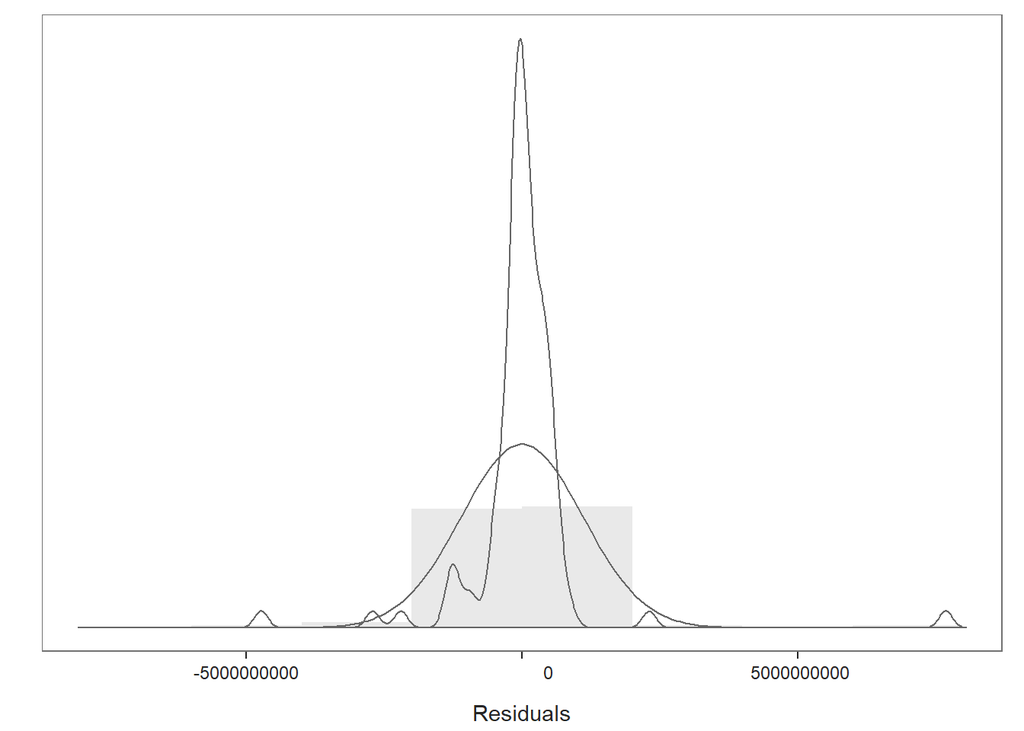

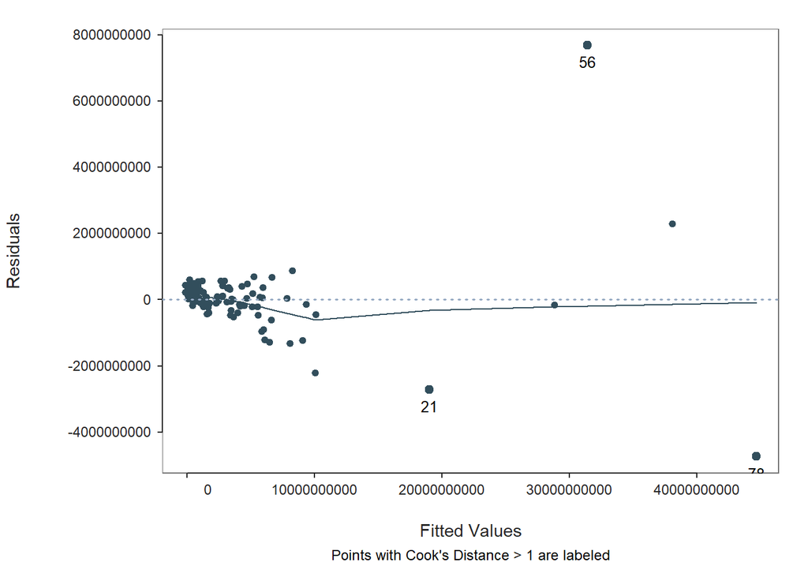

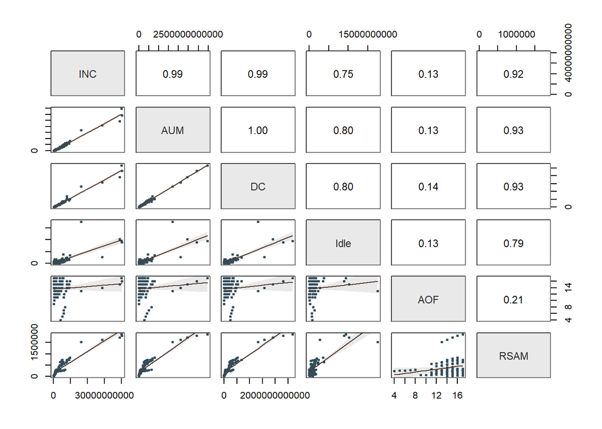

```
## >>> Suggestion
## # Create an R markdown file for interpretative output with  Rmd = "file_name"
## Regression(my_formula=INC ~ AUM + DC + Idle + AOF + RSAM, data=ThesisData_updated, Rmd="eg")
##
##
##   BACKGROUND
##
## Data Frame:  ThesisData_updated
##
## Response Variable: INC
## Predictor Variable 1: AUM
## Predictor Variable 2: DC
## Predictor Variable 3: Idle
## Predictor Variable 4: AOF
## Predictor Variable 5: RSAM
##
## Number of cases (rows) of data:  96
## Number of cases retained for analysis:  96
##
##
##   BASIC ANALYSIS
##
##                  Estimate        Std Err  t-value  p-value        Lower 95%        Upper 95%
## (Intercept) 695410397.508  637792933.681    1.090    0.278   -571676586.077   1962497381.093
##         AUM         0.009          0.003    3.503    0.001            0.004            0.014
##          DC         0.005          0.003    1.551    0.124           -0.001            0.012
##        Idle        -0.318          0.083   -3.849    0.000           -0.482           -0.154
##         AOF -44683479.208   47211942.853   -0.946    0.346   -138478244.091     49111285.676
##        RSAM      1675.343        916.676    1.828    0.071         -145.793         3496.479
##
## Standard deviation of INC: 7,411,875,780.935
##
## Standard deviation of residuals:  1,133,891,817.878 for 90 degrees of freedom
## 95% range of residual variation:  4,505,348,012.982 = 2 * (1.987 * 1,133,891,817.878)
##
## R-squared:  0.978    Adjusted R-squared:  0.977    PRESS R-squared:  0.933
##
## Null hypothesis of all 0 population slope coefficients:
##   F-statistic: 793.833     df: 5 and 90     p-value:  0.000
##
```

[output cut: 109 more lines]

```
##   54    2097120000.000    1036270000.000   184491000.000     15       29496   178763000.000    39911173.843 1153731605.542 -2252178033.692  2332000381.379 4584178415.071
## ...
##   26  157000000000.000  147000000000.000    51924000.000     14      243705  3189793000.000  2626550861.399 1144553297.915   352695963.952  4900405758.845 4547709794.893
##   24  178000000000.000  136000000000.000   250209000.000     14      287473  3197710000.000  2764417642.512 1141381492.205   496864090.718  5031971194.306 4535107103.588
##   31  177000000000.000  127000000000.000   103408000.000     13      275399  2892066000.000  2779183634.764 1142859258.000   508694243.288  5049673026.239 4540978782.951
## ...
##   80  796000000000.000  532000000000.000  3533796000.000     16      826618  9639131000.000 10090975418.341 1206780946.584  7693494435.557 12488456401.125 4794961965.568
##   21 1690000000000.000 1320000000000.000 17558452000.000     13     1537191 16312802000.000 19023108278.906 1510397445.293 16022440127.999 22023776429.813 6001336301.814
##   37 2100000000000.000 1580000000000.000  2789119000.000     14     1629790 28677346000.000 28830648128.620 1289006591.210 26269811551.064 31391484706.177 5121673155.113
##
## ----------------------------------
## Plot 1: Distribution of Residuals
## Plot 2: Residuals vs Fitted Values
## Plot 3: ScatterPlot Matrix
## ----------------------------------
```

```r
ThesisData_updated <- read.csv(file.choose(), header = T)
Regression(INC ~ AUM + DC + Idle + AOF + RSAM, data= ThesisData_updated)
```

```r
# Comment: There is perfect correlation between AUM and DC variables and very high correlation between DC and idle
```

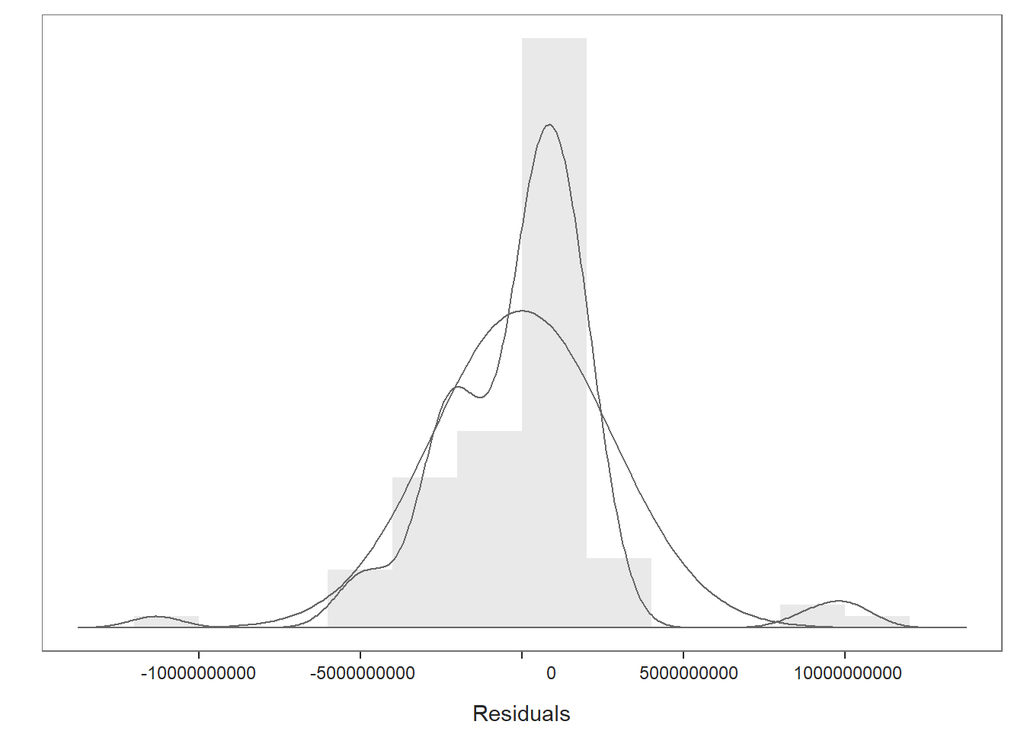

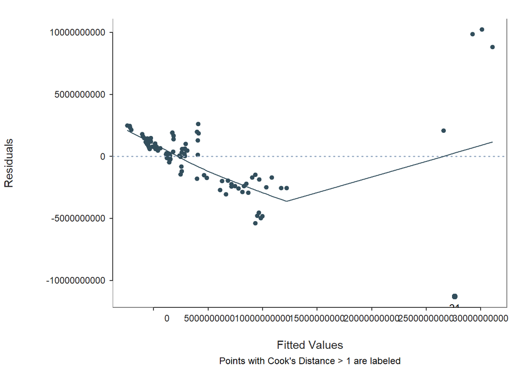

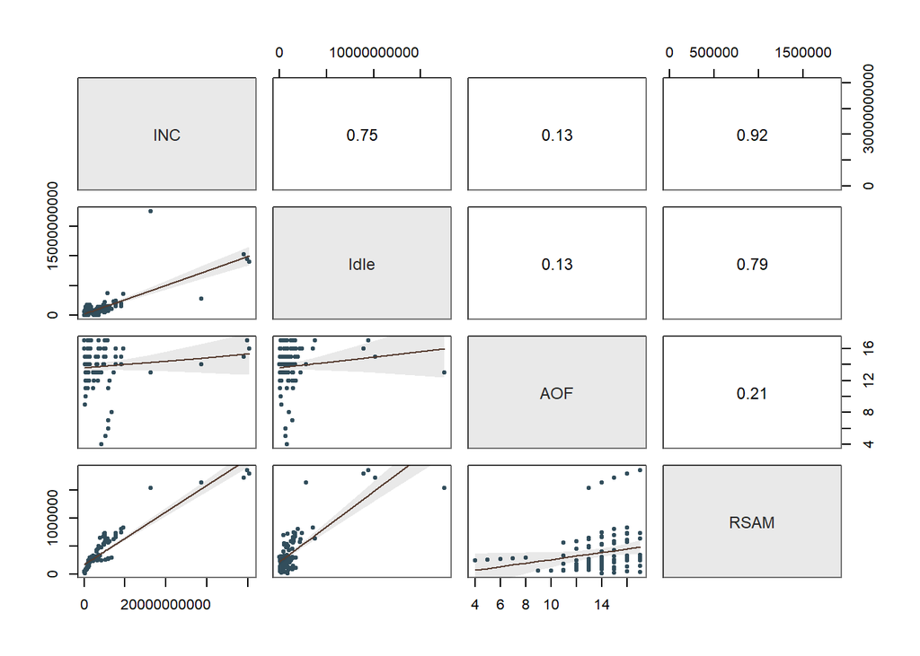

```
## >>> Suggestion
## # Create an R markdown file for interpretative output with  Rmd = "file_name"
## Regression(my_formula=INC ~ Idle + AOF + RSAM, data=ThesisData_updated, Rmd="eg")
##
##
##   BACKGROUND
##
## Data Frame:  ThesisData_updated
##
## Response Variable: INC
## Predictor Variable 1: Idle
## Predictor Variable 2: AOF
## Predictor Variable 3: RSAM
##
## Number of cases (rows) of data:  96
## Number of cases retained for analysis:  96
##
##
##   BASIC ANALYSIS
##
##                   Estimate         Std Err  t-value  p-value         Lower 95%        Upper 95%
## (Intercept)  473190798.614  1587156107.056    0.298    0.766   -2679038228.476   3625419825.705
##        Idle          0.166           0.199    0.835    0.406            -0.229            0.562
##         AOF -211660771.670   116342736.016   -1.819    0.072    -442727487.749     19405944.408
##        RSAM      17556.884        1278.615   13.731    0.000         15017.444        20096.324
##
## Standard deviation of INC: 7,411,875,780.935
##
## Standard deviation of residuals:  2,835,072,495.673 for 92 degrees of freedom
## 95% range of residual variation:  11,261,397,382.440 = 2 * (1.986 * 2,835,072,495.673)
##
## R-squared:  0.858    Adjusted R-squared:  0.854    PRESS R-squared:  0.650
##
## Null hypothesis of all 0 population slope coefficients:
##   F-statistic: 185.770     df: 3 and 92     p-value:  0.000
##
## -- Analysis of Variance
##
##             df                      Sum Sq                     Mean Sq   F-value   p-value
##      Idle    1  2959387336818753536000.000  2959387336818753536000.000   368.191     0.000
```

[output cut: 75 more lines]

```
##   54   184491000.000     15       29496   178763000.000 -2153168654.728 2873680732.189 -7860546636.215  3554209326.760 11414755962.975
## ...
##   31   103408000.000     13      275399  2892066000.000  2573953359.867 2854872757.445 -3096070360.330  8243977080.064 11340047440.395
##   24   250209000.000     14      287473  3197710000.000  2598698087.583 2853040276.541 -3067686167.365  8265082342.531 11332768509.895
##   49    12997000.000     14      303199  3048574000.000  2835332042.630 2855769904.564 -2836473489.186  8507137574.447 11343611063.633
## ...
##   37  2789119000.000     14     1629790 28677346000.000 26588007425.173 3159819081.755 20312333982.858 32863680867.488 12551346884.630
##   21 17558452000.000     13     1537191 16312802000.000 27631132303.035 3645649920.767 20390556879.005 34871707727.065 14481150848.060
##   56 10218063000.000     15     1721386 39100485000.000 29220460585.404 3063444033.920 23136196306.890 35304724863.917 12168528557.027
##
## ----------------------------------
## Plot 1: Distribution of Residuals
## Plot 2: Residuals vs Fitted Values
## Plot 3: ScatterPlot Matrix
## ----------------------------------
```

```r
Regression(INC ~ Idle + AOF + RSAM, data = ThesisData_updated)
```

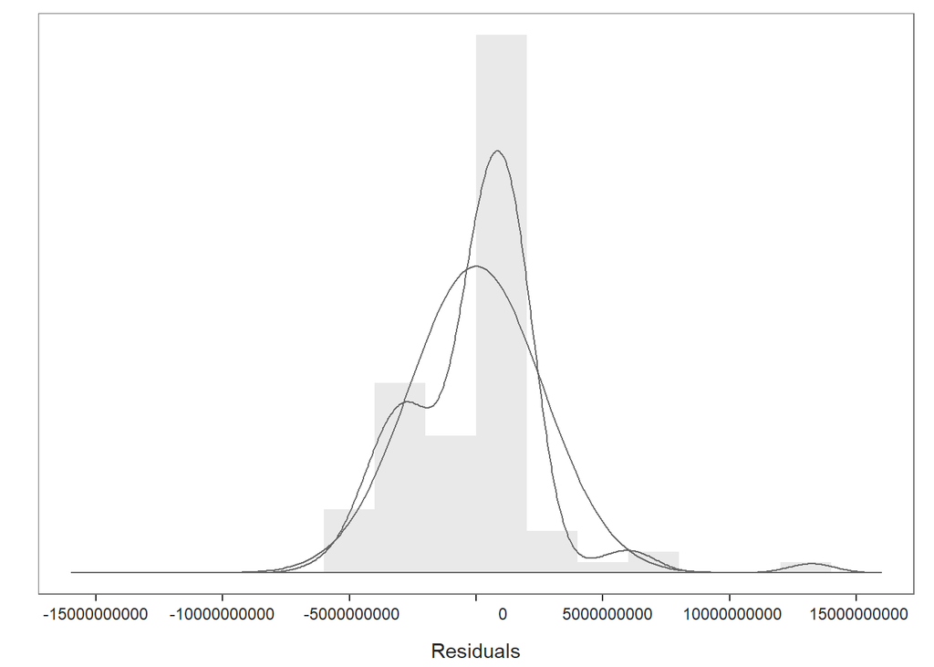

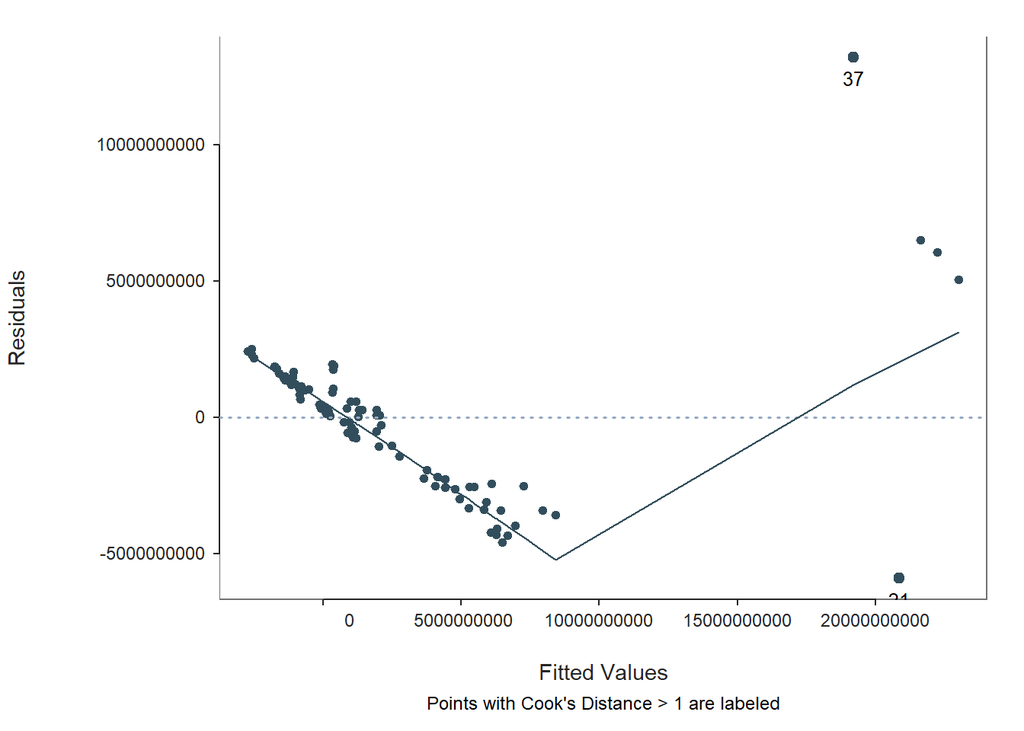

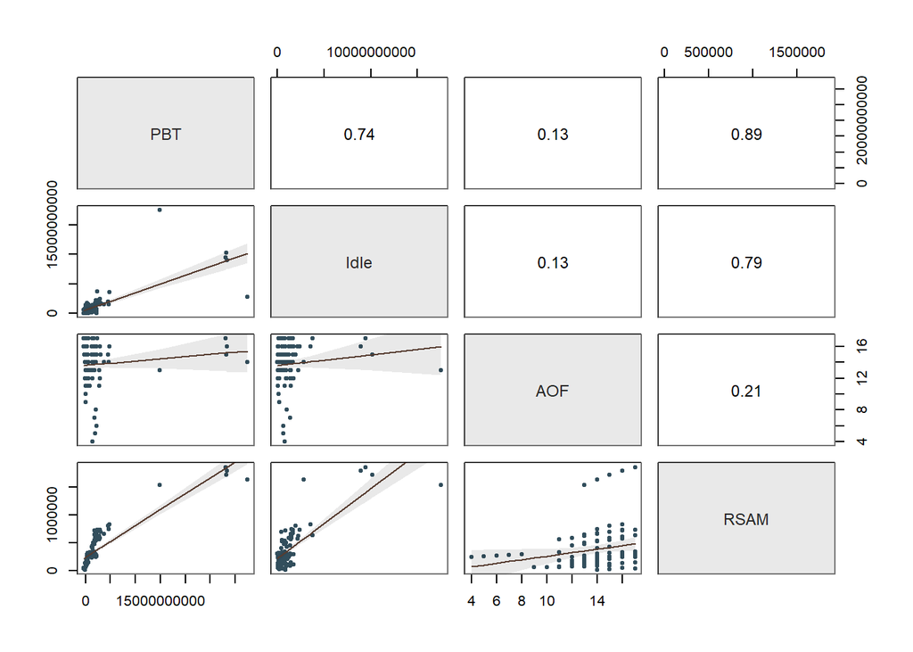

```
## >>> Suggestion
## # Create an R markdown file for interpretative output with  Rmd = "file_name"
## Regression(my_formula=PBT ~ Idle + AOF + RSAM, data=ThesisData_updated, Rmd="eg")
##
##
##   BACKGROUND
##
## Data Frame:  ThesisData_updated
##
## Response Variable: PBT
## Predictor Variable 1: Idle
## Predictor Variable 2: AOF
## Predictor Variable 3: RSAM
##
## Number of cases (rows) of data:  96
## Number of cases retained for analysis:  96
##
##
##   BASIC ANALYSIS
##
##                   Estimate         Std Err  t-value  p-value         Lower 95%        Upper 95%
## (Intercept) -844717770.553  1498854076.763   -0.564    0.574   -3821571343.518   2132135802.411
##        Idle          0.186           0.188    0.989    0.325            -0.188            0.560
##         AOF -143914897.640   109869963.896   -1.310    0.194    -362126129.578     74296334.298
##        RSAM      13209.264        1207.479   10.940    0.000         10811.107        15607.421
##
## Standard deviation of PBT: 5,910,530,563.558
##
## Standard deviation of residuals:  2,677,342,165.124 for 92 degrees of freedom
## 95% range of residual variation:  10,634,865,279.898 = 2 * (1.986 * 2,677,342,165.124)
##
## R-squared:  0.801    Adjusted R-squared:  0.795    PRESS R-squared:  0.665
##
## Null hypothesis of all 0 population slope coefficients:
##   F-statistic: 123.662     df: 3 and 92     p-value:  0.000
##
## -- Analysis of Variance
##
##             df                      Sum Sq                     Mean Sq   F-value   p-value
##      Idle    1  1797476566424363991040.000  1797476566424363991040.000   250.758     0.000
```

[output cut: 75 more lines]

```
##   54   184491000.000     15       29496  -269394000.000 -2579501962.338 2713802417.800 -7969347811.239  2810343886.564 10779691697.804
## ...
##   31   103408000.000     13      275399   770800000.000   941442432.440 2696040831.844 -4413127373.627  6296012238.506 10709139612.133
##   24   250209000.000     14      287473  1550913000.000   984323959.174 2694310301.708 -4366808864.669  6335456783.016 10702265647.685
##   91  1336066000.000     17      308887   653470000.000  1037432465.171 2718705864.135 -4362152051.402  6437016981.743 10799169033.146
## ...
##   37  2789119000.000     14     1629790 32408939000.000 19187628694.406 2984021352.068 13261104717.575 25114152671.238 11853047953.663
##   21 17558452000.000     13     1537191 14938077000.000 20855755430.394 3442822808.605 14018012158.535 27693498702.252 13675486543.717
##   56 10218063000.000     15     1721386 28149284000.000 21635554197.735 2893008166.468 15889790263.484 27381318131.986 11491527868.502
##
## ----------------------------------
## Plot 1: Distribution of Residuals
## Plot 2: Residuals vs Fitted Values
## Plot 3: ScatterPlot Matrix
## ----------------------------------
```

```r
Regression(PBT ~ Idle + AOF + RSAM, data = ThesisData_updated)
```

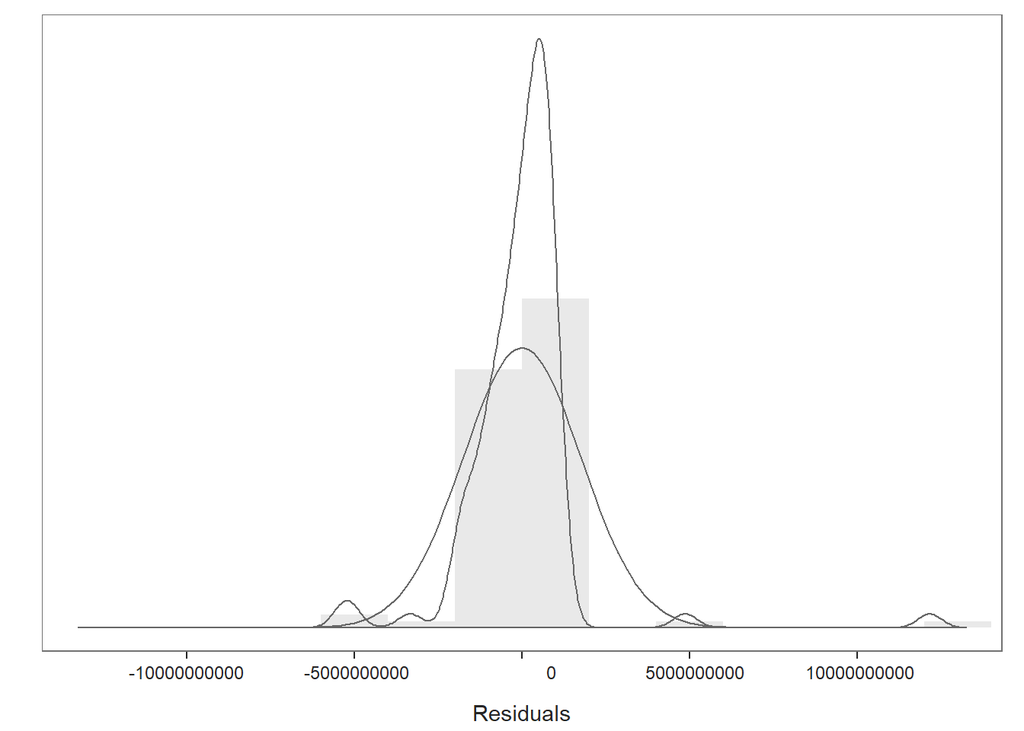

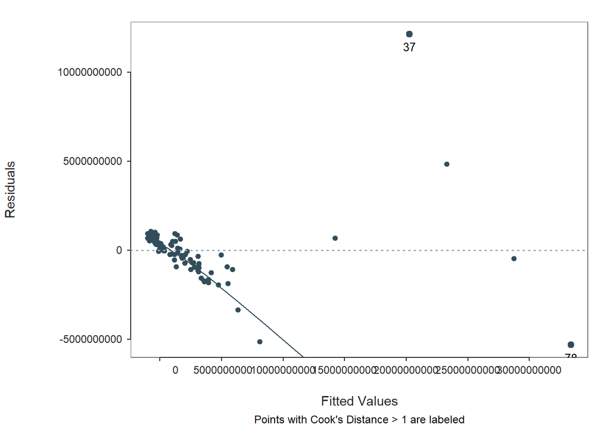

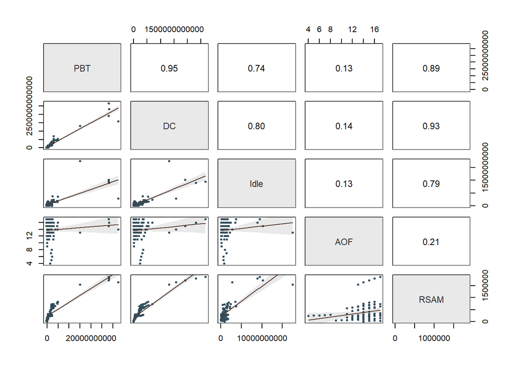

```
## >>> Suggestion
## # Create an R markdown file for interpretative output with  Rmd = "file_name"
## Regression(my_formula=PBT ~ DC + Idle + AOF + RSAM, data=ThesisData_updated, Rmd="eg")
##
##
##   BACKGROUND
##
## Data Frame:  ThesisData_updated
##
## Response Variable: PBT
## Predictor Variable 1: DC
## Predictor Variable 2: Idle
## Predictor Variable 3: AOF
## Predictor Variable 4: RSAM
##
## Number of cases (rows) of data:  96
## Number of cases retained for analysis:  96
##
##
##   BASIC ANALYSIS
##
##                   Estimate         Std Err  t-value  p-value         Lower 95%        Upper 95%
## (Intercept) -514131940.529  1010463006.510   -0.509    0.612   -2521292572.046   1493028690.988
##          DC          0.013           0.001   10.565    0.000             0.011            0.016
##        Idle         -0.176           0.131   -1.338    0.184            -0.436            0.085
##         AOF  -24823703.771    74887304.115   -0.331    0.741    -173578133.821    123930726.278
##        RSAM        594.495        1444.878    0.411    0.682         -2275.578         3464.567
##
## Standard deviation of PBT: 5,910,530,563.558
##
## Standard deviation of residuals:  1,804,083,416.387 for 91 degrees of freedom
## 95% range of residual variation:  7,167,180,165.955 = 2 * (1.986 * 1,804,083,416.387)
##
## R-squared:  0.911    Adjusted R-squared:  0.907    PRESS R-squared:  0.847
##
## Null hypothesis of all 0 population slope coefficients:
##   F-statistic: 232.170     df: 4 and 91     p-value:  0.000
##
## -- Analysis of Variance
##
```

[output cut: 88 more lines]

```
##   54    1036270000.000   184491000.000     15       29496  -269394000.000  -887827755.243 1835648378.117 -4534117757.081  2758462246.595 7292580003.675
## ...
##   11  129000000000.000    80427000.000     13      230121  1255167000.000   970894681.767 1817306309.310 -2638961053.627  4580750417.161 7219711470.788
##   24  136000000000.000   250209000.000     14      287473  1550913000.000  1041776111.250 1815525262.918 -2564541794.281  4648094016.780 7212635811.061
##    2  145000000000.000   809924000.000     11      324651   929089000.000  1157579814.325 1826563532.450 -2470664257.628  4785823886.278 7256488143.906
## ...
##   79  689000000000.000  2417821000.000     16      730155  2969544000.000  8098036637.862 1830399124.670  4462173633.149 11733899642.574 7271726009.425
##   21 1320000000000.000 17558452000.000     13     1537191 14938077000.000 14234771014.793 2403045586.784  9461416160.179 19008125869.408 9546709709.229
##   37 1580000000000.000  2789119000.000     14     1629790 32408939000.000 20255942703.233 2013275145.928 16256818947.802 24255066458.664 7998247510.862
##
## ----------------------------------
## Plot 1: Distribution of Residuals
## Plot 2: Residuals vs Fitted Values
## Plot 3: ScatterPlot Matrix
## ----------------------------------
```

```r
Regression(PBT ~ DC + Idle + AOF + RSAM, data = ThesisData_updated)
```